# Risk Factor Analysis

## Outcome Variable

**Outcome Variable:** ever_stunted

## Predictor Variables

**Intervention Variable:** tr

**Adjustment Set:**

unadjusted

## Stratifying Variables

The analysis was stratified on these variable(s):

- agecat
- studyid
- country
- intXgagebrth

## Data Summary

| agecat | studyid | country | intXgagebrth | ever_stunted | n_cell | n |
| --- | --- | --- | --- | --- | --- | --- |
| 0-6 months | iLiNS_DYADM_LNS | MALAWI | Full or late term_0-6 months | 0 | 24 | 29 |
| 0-6 months | iLiNS_DYADM_LNS | MALAWI | Full or late term_0-6 months | 1 | 5 | 29 |
| 0-6 months | iLiNS_DYADM_LNS | MALAWI | Preterm_0-6 months | 0 | 0 | 2 |
| 0-6 months | iLiNS_DYADM_LNS | MALAWI | Preterm_0-6 months | 1 | 2 | 2 |
| 0-6 months | iLiNS_DYADM_LNS | MALAWI | Early term_0-6 months | 0 | 9 | 12 |
| 0-6 months | iLiNS_DYADM_LNS | MALAWI | Early term_0-6 months | 1 | 3 | 12 |
| 0-6 months | ki1000304b-SAS-CompFeed | INDIA | Full or late term_0-6 months | 0 | 16 | 17 |
| 0-6 months | ki1000304b-SAS-CompFeed | INDIA | Full or late term_0-6 months | 1 | 1 | 17 |
| 0-6 months | ki1000304b-SAS-CompFeed | INDIA | Preterm_0-6 months | 0 | 515 | 721 |
| 0-6 months | ki1000304b-SAS-CompFeed | INDIA | Preterm_0-6 months | 1 | 206 | 721 |
| 0-6 months | ki1000304b-SAS-CompFeed | INDIA | Early term_0-6 months | 0 | 36 | 50 |
| 0-6 months | ki1000304b-SAS-CompFeed | INDIA | Early term_0-6 months | 1 | 14 | 50 |
| 0-6 months | ki1066203-TanzaniaChild2 | TANZANIA, UNITED REPUBLIC OF | Full or late term_0-6 months | 0 | 1224 | 1295 |
| 0-6 months | ki1066203-TanzaniaChild2 | TANZANIA, UNITED REPUBLIC OF | Full or late term_0-6 months | 1 | 71 | 1295 |
| 0-6 months | ki1066203-TanzaniaChild2 | TANZANIA, UNITED REPUBLIC OF | Preterm_0-6 months | 0 | 282 | 323 |
| 0-6 months | ki1066203-TanzaniaChild2 | TANZANIA, UNITED REPUBLIC OF | Preterm_0-6 months | 1 | 41 | 323 |
| 0-6 months | ki1066203-TanzaniaChild2 | TANZANIA, UNITED REPUBLIC OF | Early term_0-6 months | 0 | 444 | 482 |
| 0-6 months | ki1066203-TanzaniaChild2 | TANZANIA, UNITED REPUBLIC OF | Early term_0-6 months | 1 | 38 | 482 |
| 0-6 months | ki1119695-PROBIT | BELARUS | Full or late term_0-6 months | 0 | 7835 | 8280 |
| 0-6 months | ki1119695-PROBIT | BELARUS | Full or late term_0-6 months | 1 | 445 | 8280 |
| 0-6 months | ki1119695-PROBIT | BELARUS | Preterm_0-6 months | 0 | 482 | 568 |
| 0-6 months | ki1119695-PROBIT | BELARUS | Preterm_0-6 months | 1 | 86 | 568 |
| 0-6 months | ki1119695-PROBIT | BELARUS | Early term_0-6 months | 0 | 6816 | 7337 |
| 0-6 months | ki1119695-PROBIT | BELARUS | Early term_0-6 months | 1 | 521 | 7337 |
| 0-6 months | ki1135781-COHORTS | GUATEMALA | Full or late term_0-6 months | 0 | 75 | 103 |
| 0-6 months | ki1135781-COHORTS | GUATEMALA | Full or late term_0-6 months | 1 | 28 | 103 |
| 0-6 months | ki1135781-COHORTS | GUATEMALA | Preterm_0-6 months | 0 | 13 | 23 |
| 0-6 months | ki1135781-COHORTS | GUATEMALA | Preterm_0-6 months | 1 | 10 | 23 |
| 0-6 months | ki1135781-COHORTS | GUATEMALA | Early term_0-6 months | 0 | 42 | 63 |
| 0-6 months | ki1135781-COHORTS | GUATEMALA | Early term_0-6 months | 1 | 21 | 63 |

[output cut: 54 more lines]

The following strata were considered:

- agecat: 0-6 months, studyid: iLiNS_DYADM_LNS, country: MALAWI, intXgagebrth: Early term_0-6 months
- agecat: 0-6 months, studyid: iLiNS_DYADM_LNS, country: MALAWI, intXgagebrth: Full or late term_0-6 months
- agecat: 0-6 months, studyid: iLiNS_DYADM_LNS, country: MALAWI, intXgagebrth: Preterm_0-6 months
- agecat: 0-6 months, studyid: ki1000304b-SAS-CompFeed, country: INDIA, intXgagebrth: Early term_0-6 months
- agecat: 0-6 months, studyid: ki1000304b-SAS-CompFeed, country: INDIA, intXgagebrth: Full or late term_0-6 months
- agecat: 0-6 months, studyid: ki1000304b-SAS-CompFeed, country: INDIA, intXgagebrth: Preterm_0-6 months
- agecat: 0-6 months, studyid: ki1066203-TanzaniaChild2, country: TANZANIA, UNITED REPUBLIC OF, intXgagebrth: Early term_0-6 months
- agecat: 0-6 months, studyid: ki1066203-TanzaniaChild2, country: TANZANIA, UNITED REPUBLIC OF, intXgagebrth: Full or late term_0-6 months
- agecat: 0-6 months, studyid: ki1066203-TanzaniaChild2, country: TANZANIA, UNITED REPUBLIC OF, intXgagebrth: Preterm_0-6 months
- agecat: 0-6 months, studyid: ki1119695-PROBIT, country: BELARUS, intXgagebrth: Early term_0-6 months
- agecat: 0-6 months, studyid: ki1119695-PROBIT, country: BELARUS, intXgagebrth: Full or late term_0-6 months
- agecat: 0-6 months, studyid: ki1119695-PROBIT, country: BELARUS, intXgagebrth: Preterm_0-6 months
- agecat: 0-6 months, studyid: ki1135781-COHORTS, country: GUATEMALA, intXgagebrth: Early term_0-6 months
- agecat: 0-6 months, studyid: ki1135781-COHORTS, country: GUATEMALA, intXgagebrth: Full or late term_0-6 months
- agecat: 0-6 months, studyid: ki1135781-COHORTS, country: GUATEMALA, intXgagebrth: Preterm_0-6 months
- agecat: 0-6 months, studyid: ki1148112-iLiNS-DYAD-M, country: MALAWI, intXgagebrth: Early term_0-6 months
- agecat: 0-6 months, studyid: ki1148112-iLiNS-DYAD-M, country: MALAWI, intXgagebrth: Full or late term_0-6 months
- agecat: 0-6 months, studyid: ki1148112-iLiNS-DYAD-M, country: MALAWI, intXgagebrth: Preterm_0-6 months
- agecat: 0-6 months, studyid: kiGH5241-JiVitA-3, country: BANGLADESH, intXgagebrth: Early term_0-6 months
- agecat: 0-6 months, studyid: kiGH5241-JiVitA-3, country: BANGLADESH, intXgagebrth: Full or late term_0-6 months
- agecat: 0-6 months, studyid: kiGH5241-JiVitA-3, country: BANGLADESH, intXgagebrth: Preterm_0-6 months
- agecat: 6-24 months, studyid: iLiNS_DYADM_LNS, country: MALAWI, intXgagebrth: Early term_6-24 months
- agecat: 6-24 months, studyid: iLiNS_DYADM_LNS, country: MALAWI, intXgagebrth: Full or late term_6-24 months
- agecat: 6-24 months, studyid: iLiNS_DYADM_LNS, country: MALAWI, intXgagebrth: Preterm_6-24 months
- agecat: 6-24 months, studyid: ki1000304b-SAS-CompFeed, country: INDIA, intXgagebrth: Early term_6-24 months
- agecat: 6-24 months, studyid: ki1000304b-SAS-CompFeed, country: INDIA, intXgagebrth: Full or late term_6-24 months
- agecat: 6-24 months, studyid: ki1000304b-SAS-CompFeed, country: INDIA, intXgagebrth: Preterm_6-24 months
- agecat: 6-24 months, studyid: ki1066203-TanzaniaChild2, country: TANZANIA, UNITED REPUBLIC OF, intXgagebrth: Early term_6-24 months
- agecat: 6-24 months, studyid: ki1066203-TanzaniaChild2, country: TANZANIA, UNITED REPUBLIC OF, intXgagebrth: Full or late term_6-24 months
- agecat: 6-24 months, studyid: ki1066203-TanzaniaChild2, country: TANZANIA, UNITED REPUBLIC OF, intXgagebrth: Preterm_6-24 months
- agecat: 6-24 months, studyid: ki1119695-PROBIT, country: BELARUS, intXgagebrth: Early term_6-24 months
- agecat: 6-24 months, studyid: ki1119695-PROBIT, country: BELARUS, intXgagebrth: Full or late term_6-24 months
- agecat: 6-24 months, studyid: ki1119695-PROBIT, country: BELARUS, intXgagebrth: Preterm_6-24 months
- agecat: 6-24 months, studyid: ki1135781-COHORTS, country: GUATEMALA, intXgagebrth: Early term_6-24 months
- agecat: 6-24 months, studyid: ki1135781-COHORTS, country: GUATEMALA, intXgagebrth: Full or late term_6-24 months
- agecat: 6-24 months, studyid: ki1135781-COHORTS, country: GUATEMALA, intXgagebrth: Preterm_6-24 months
- agecat: 6-24 months, studyid: ki1148112-iLiNS-DYAD-M, country: MALAWI, intXgagebrth: Early term_6-24 months
- agecat: 6-24 months, studyid: ki1148112-iLiNS-DYAD-M, country: MALAWI, intXgagebrth: Full or late term_6-24 months
- agecat: 6-24 months, studyid: ki1148112-iLiNS-DYAD-M, country: MALAWI, intXgagebrth: Preterm_6-24 months
- agecat: 6-24 months, studyid: kiGH5241-JiVitA-3, country: BANGLADESH, intXgagebrth: Early term_6-24 months
- agecat: 6-24 months, studyid: kiGH5241-JiVitA-3, country: BANGLADESH, intXgagebrth: Full or late term_6-24 months
- agecat: 6-24 months, studyid: kiGH5241-JiVitA-3, country: BANGLADESH, intXgagebrth: Preterm_6-24 months

### Dropped Strata

Some strata were dropped due to rare outcomes:

- agecat: 0-6 months, studyid: iLiNS_DYADM_LNS, country: MALAWI, intXgagebrth: Preterm_0-6 months
- agecat: 0-6 months, studyid: iLiNS_DYADM_LNS, country: MALAWI, intXgagebrth: Early term_0-6 months
- agecat: 0-6 months, studyid: ki1000304b-SAS-CompFeed, country: INDIA, intXgagebrth: Full or late term_0-6 months
- agecat: 0-6 months, studyid: ki1148112-iLiNS-DYAD-M, country: MALAWI, intXgagebrth: Preterm_0-6 months
- agecat: 0-6 months, studyid: ki1148112-iLiNS-DYAD-M, country: MALAWI, intXgagebrth: Early term_0-6 months

## Methods Detail

We’re interested in the causal parameters $E[Y_a]$ for all values of $a \in \mathcal{A}$. These parameters represent the mean outcome if, possibly contrary to fact, we intervened to set all units to have $A=a$. Under the randomization and positivity assumptions, these are identified by the statistical parameters $\psi_a=E_W[E_{Y|A,W}(Y|A=a,W)]$. In addition, we’re interested in the mean of $Y$, $E[Y]$ under no intervention (the observed mean). We will estimate these parameters by using SuperLearner to fit the relevant likelihood factors – $E_{Y|A,W}(Y|A=a,W)$ and $p(A=a|W)$, and then updating our likelihood fit using a joint TMLE.

For unadjusted analyses ($W=\{\}$), initial likelihoods were estimated using Lrnr_glm to estimate the simple $E(Y|A)$ and Lrnr_mean to estimate $p(A)$. For adjusted analyses, a small library containing Lrnr_glmnet, Lrnr_xgboost, and Lrnr_mean was used.

Having estimated these parameters, we will then use the delta method to estimate relative risks and attributable risks relative to a prespecified baseline level of $A$.

# Results Detail

## Results Plots

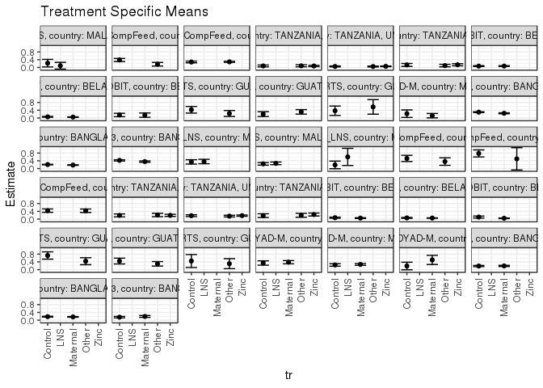

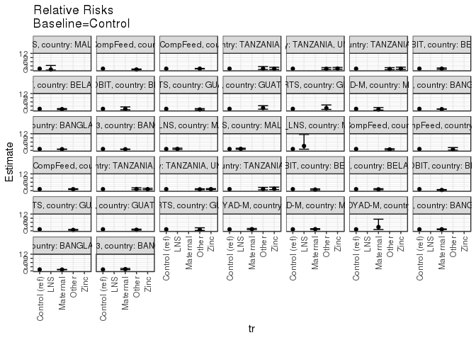

[figure not shown]

[figure not shown]

## Results Table

### Parameter: TSM

| agecat | studyid | country | intXgagebrth | intervention_level | baseline_level | estimate | ci_lower | ci_upper |
| --- | --- | --- | --- | --- | --- | --- | --- | --- |
| 0-6 months | iLiNS_DYADM_LNS | MALAWI | Full or late term_0-6 months | Control | NA | 0.2222222 | 0.0267643 | 0.4176802 |
| 0-6 months | iLiNS_DYADM_LNS | MALAWI | Full or late term_0-6 months | LNS | NA | 0.0909091 | -0.0819846 | 0.2638028 |
| 0-6 months | ki1000304b-SAS-CompFeed | INDIA | Preterm_0-6 months | Control | NA | 0.2818182 | 0.2388992 | 0.3247372 |
| 0-6 months | ki1000304b-SAS-CompFeed | INDIA | Preterm_0-6 months | Other | NA | 0.2890026 | 0.2619776 | 0.3160275 |
| 0-6 months | ki1000304b-SAS-CompFeed | INDIA | Early term_0-6 months | Control | NA | 0.3846154 | 0.3053017 | 0.4639290 |
| 0-6 months | ki1000304b-SAS-CompFeed | INDIA | Early term_0-6 months | Other | NA | 0.1666667 | 0.0739890 | 0.2593443 |
| 0-6 months | ki1066203-TanzaniaChild2 | TANZANIA, UNITED REPUBLIC OF | Full or late term_0-6 months | Control | NA | 0.0532915 | 0.0286335 | 0.0779495 |
| 0-6 months | ki1066203-TanzaniaChild2 | TANZANIA, UNITED REPUBLIC OF | Full or late term_0-6 months | Other | NA | 0.0496894 | 0.0259455 | 0.0734334 |
| 0-6 months | ki1066203-TanzaniaChild2 | TANZANIA, UNITED REPUBLIC OF | Full or late term_0-6 months | Zinc | NA | 0.0581040 | 0.0401677 | 0.0760402 |
| 0-6 months | ki1066203-TanzaniaChild2 | TANZANIA, UNITED REPUBLIC OF | Preterm_0-6 months | Control | NA | 0.1315789 | 0.0554635 | 0.2076944 |
| 0-6 months | ki1066203-TanzaniaChild2 | TANZANIA, UNITED REPUBLIC OF | Preterm_0-6 months | Other | NA | 0.0975610 | 0.0332387 | 0.1618833 |
| 0-6 months | ki1066203-TanzaniaChild2 | TANZANIA, UNITED REPUBLIC OF | Preterm_0-6 months | Zinc | NA | 0.1393939 | 0.0864637 | 0.1923241 |
| 0-6 months | ki1066203-TanzaniaChild2 | TANZANIA, UNITED REPUBLIC OF | Early term_0-6 months | Control | NA | 0.0787402 | 0.0318495 | 0.1256308 |
| 0-6 months | ki1066203-TanzaniaChild2 | TANZANIA, UNITED REPUBLIC OF | Early term_0-6 months | Other | NA | 0.0849057 | 0.0317870 | 0.1380244 |
| 0-6 months | ki1066203-TanzaniaChild2 | TANZANIA, UNITED REPUBLIC OF | Early term_0-6 months | Zinc | NA | 0.0763052 | 0.0432956 | 0.1093149 |
| 0-6 months | ki1119695-PROBIT | BELARUS | Full or late term_0-6 months | Control | NA | 0.0607133 | 0.0407084 | 0.0807183 |
| 0-6 months | ki1119695-PROBIT | BELARUS | Full or late term_0-6 months | Maternal | NA | 0.0481875 | 0.0362675 | 0.0601076 |
| 0-6 months | ki1119695-PROBIT | BELARUS | Preterm_0-6 months | Control | NA | 0.1558442 | 0.0684355 | 0.2432528 |
| 0-6 months | ki1119695-PROBIT | BELARUS | Preterm_0-6 months | Maternal | NA | 0.1483680 | 0.0377177 | 0.2590182 |
| 0-6 months | ki1119695-PROBIT | BELARUS | Early term_0-6 months | Control | NA | 0.0702024 | 0.0491518 | 0.0912530 |
| 0-6 months | ki1119695-PROBIT | BELARUS | Early term_0-6 months | Maternal | NA | 0.0719278 | 0.0508805 | 0.0929750 |
| 0-6 months | ki1135781-COHORTS | GUATEMALA | Full or late term_0-6 months | Control | NA | 0.2000000 | 0.0754348 | 0.3245652 |
| 0-6 months | ki1135781-COHORTS | GUATEMALA | Full or late term_0-6 months | Other | NA | 0.3174603 | 0.2019542 | 0.4329664 |
| 0-6 months | ki1135781-COHORTS | GUATEMALA | Preterm_0-6 months | Control | NA | 0.3750000 | 0.1324528 | 0.6175472 |
| 0-6 months | ki1135781-COHORTS | GUATEMALA | Preterm_0-6 months | Other | NA | 0.5714286 | 0.1965900 | 0.9462671 |
| 0-6 months | ki1135781-COHORTS | GUATEMALA | Early term_0-6 months | Control | NA | 0.4242424 | 0.2542645 | 0.5942203 |
| 0-6 months | ki1135781-COHORTS | GUATEMALA | Early term_0-6 months | Other | NA | 0.2333333 | 0.0807688 | 0.3858979 |
| 0-6 months | ki1148112-iLiNS-DYAD-M | MALAWI | Full or late term_0-6 months | Control | NA | 0.2222222 | 0.0282527 | 0.4161917 |
| 0-6 months | ki1148112-iLiNS-DYAD-M | MALAWI | Full or late term_0-6 months | Maternal | NA | 0.1212121 | 0.0087500 | 0.2336742 |
| 0-6 months | kiGH5241-JiVitA-3 | BANGLADESH | Full or late term_0-6 months | Control | NA | 0.2058577 | 0.1914144 | 0.2203011 |
| 0-6 months | kiGH5241-JiVitA-3 | BANGLADESH | Full or late term_0-6 months | Maternal | NA | 0.1803789 | 0.1664415 | 0.1943163 |
| 0-6 months | kiGH5241-JiVitA-3 | BANGLADESH | Preterm_0-6 months | Control | NA | 0.4215040 | 0.3910526 | 0.4519553 |
| 0-6 months | kiGH5241-JiVitA-3 | BANGLADESH | Preterm_0-6 months | Maternal | NA | 0.3587278 | 0.3235694 | 0.3938862 |
| 0-6 months | kiGH5241-JiVitA-3 | BANGLADESH | Early term_0-6 months | Control | NA | 0.3013766 | 0.2789722 | 0.3237810 |
| 0-6 months | kiGH5241-JiVitA-3 | BANGLADESH | Early term_0-6 months | Maternal | NA | 0.2438776 | 0.2216686 | 0.2660865 |
| 6-24 months | iLiNS_DYADM_LNS | MALAWI | Full or late term_6-24 months | Control | NA | 0.2411765 | 0.1765788 | 0.3057741 |
| 6-24 months | iLiNS_DYADM_LNS | MALAWI | Full or late term_6-24 months | LNS | NA | 0.2682927 | 0.2002522 | 0.3363331 |
| 6-24 months | iLiNS_DYADM_LNS | MALAWI | Preterm_6-24 months | Control | NA | 0.1875000 | -0.0084725 | 0.3834725 |
| 6-24 months | iLiNS_DYADM_LNS | MALAWI | Preterm_6-24 months | LNS | NA | 0.6000000 | 0.1599892 | 1.0400108 |
| 6-24 months | iLiNS_DYADM_LNS | MALAWI | Early term_6-24 months | Control | NA | 0.3428571 | 0.2312599 | 0.4544544 |
| 6-24 months | iLiNS_DYADM_LNS | MALAWI | Early term_6-24 months | LNS | NA | 0.3623188 | 0.2484936 | 0.4761441 |
| 6-24 months | ki1000304b-SAS-CompFeed | INDIA | Full or late term_6-24 months | Control | NA | 0.7777778 | 0.5967620 | 0.9587935 |
| 6-24 months | ki1000304b-SAS-CompFeed | INDIA | Full or late term_6-24 months | Other | NA | 0.5000000 | -0.0722808 | 1.0722808 |
| 6-24 months | ki1000304b-SAS-CompFeed | INDIA | Preterm_6-24 months | Control | NA | 0.4351145 | 0.3489338 | 0.5212952 |
| 6-24 months | ki1000304b-SAS-CompFeed | INDIA | Preterm_6-24 months | Other | NA | 0.4300000 | 0.3405626 | 0.5194374 |
| 6-24 months | ki1000304b-SAS-CompFeed | INDIA | Early term_6-24 months | Control | NA | 0.5217391 | 0.3624006 | 0.6810777 |
| 6-24 months | ki1000304b-SAS-CompFeed | INDIA | Early term_6-24 months | Other | NA | 0.3600000 | 0.1667895 | 0.5532105 |
| 6-24 months | ki1066203-TanzaniaChild2 | TANZANIA, UNITED REPUBLIC OF | Full or late term_6-24 months | Control | NA | 0.1750973 | 0.1286106 | 0.2215839 |
| 6-24 months | ki1066203-TanzaniaChild2 | TANZANIA, UNITED REPUBLIC OF | Full or late term_6-24 months | Other | NA | 0.1529851 | 0.1098673 | 0.1961029 |
| 6-24 months | ki1066203-TanzaniaChild2 | TANZANIA, UNITED REPUBLIC OF | Full or late term_6-24 months | Zinc | NA | 0.1789077 | 0.1462927 | 0.2115227 |
| 6-24 months | ki1066203-TanzaniaChild2 | TANZANIA, UNITED REPUBLIC OF | Preterm_6-24 months | Control | NA | 0.1774194 | 0.0821339 | 0.2727048 |
| 6-24 months | ki1066203-TanzaniaChild2 | TANZANIA, UNITED REPUBLIC OF | Preterm_6-24 months | Other | NA | 0.1967213 | 0.0967613 | 0.2966814 |
| 6-24 months | ki1066203-TanzaniaChild2 | TANZANIA, UNITED REPUBLIC OF | Preterm_6-24 months | Zinc | NA | 0.2357724 | 0.1606035 | 0.3109412 |
| 6-24 months | ki1066203-TanzaniaChild2 | TANZANIA, UNITED REPUBLIC OF | Early term_6-24 months | Control | NA | 0.1904762 | 0.1152718 | 0.2656806 |
| 6-24 months | ki1066203-TanzaniaChild2 | TANZANIA, UNITED REPUBLIC OF | Early term_6-24 months | Other | NA | 0.2117647 | 0.1247990 | 0.2987304 |
| 6-24 months | ki1066203-TanzaniaChild2 | TANZANIA, UNITED REPUBLIC OF | Early term_6-24 months | Zinc | NA | 0.1930693 | 0.1385686 | 0.2475700 |
| 6-24 months | ki1119695-PROBIT | BELARUS | Full or late term_6-24 months | Control | NA | 0.0608856 | 0.0365614 | 0.0852099 |
| 6-24 months | ki1119695-PROBIT | BELARUS | Full or late term_6-24 months | Maternal | NA | 0.0535459 | 0.0438690 | 0.0632228 |
| 6-24 months | ki1119695-PROBIT | BELARUS | Preterm_6-24 months | Control | NA | 0.1042945 | 0.0526631 | 0.1559258 |
| 6-24 months | ki1119695-PROBIT | BELARUS | Preterm_6-24 months | Maternal | NA | 0.0423077 | 0.0256849 | 0.0589304 |
| 6-24 months | ki1119695-PROBIT | BELARUS | Early term_6-24 months | Control | NA | 0.0716867 | 0.0442084 | 0.0991651 |
| 6-24 months | ki1119695-PROBIT | BELARUS | Early term_6-24 months | Maternal | NA | 0.0518272 | 0.0327988 | 0.0708557 |
| 6-24 months | ki1135781-COHORTS | GUATEMALA | Full or late term_6-24 months | Control | NA | 0.4418605 | 0.2927025 | 0.5910184 |
| 6-24 months | ki1135781-COHORTS | GUATEMALA | Full or late term_6-24 months | Other | NA | 0.3000000 | 0.1834800 | 0.4165200 |
| 6-24 months | ki1135781-COHORTS | GUATEMALA | Preterm_6-24 months | Control | NA | 0.4444444 | 0.1121669 | 0.7767220 |
| 6-24 months | ki1135781-COHORTS | GUATEMALA | Preterm_6-24 months | Other | NA | 0.3076923 | 0.0508976 | 0.5644870 |
| 6-24 months | ki1135781-COHORTS | GUATEMALA | Early term_6-24 months | Control | NA | 0.7272727 | 0.5393556 | 0.9151898 |
| 6-24 months | ki1135781-COHORTS | GUATEMALA | Early term_6-24 months | Other | NA | 0.4333333 | 0.2542814 | 0.6123852 |
| 6-24 months | ki1148112-iLiNS-DYAD-M | MALAWI | Full or late term_6-24 months | Control | NA | 0.2411765 | 0.1766843 | 0.3056686 |
| 6-24 months | ki1148112-iLiNS-DYAD-M | MALAWI | Full or late term_6-24 months | Maternal | NA | 0.2683616 | 0.2220942 | 0.3146289 |
| 6-24 months | ki1148112-iLiNS-DYAD-M | MALAWI | Preterm_6-24 months | Control | NA | 0.1875000 | -0.0066256 | 0.3816256 |
| 6-24 months | ki1148112-iLiNS-DYAD-M | MALAWI | Preterm_6-24 months | Maternal | NA | 0.5000000 | 0.2655424 | 0.7344576 |
| 6-24 months | ki1148112-iLiNS-DYAD-M | MALAWI | Early term_6-24 months | Control | NA | 0.3428571 | 0.2313872 | 0.4543271 |
| 6-24 months | ki1148112-iLiNS-DYAD-M | MALAWI | Early term_6-24 months | Maternal | NA | 0.3834586 | 0.3006196 | 0.4662977 |
| 6-24 months | kiGH5241-JiVitA-3 | BANGLADESH | Full or late term_6-24 months | Control | NA | 0.1813778 | 0.1595491 | 0.2032065 |
| 6-24 months | kiGH5241-JiVitA-3 | BANGLADESH | Full or late term_6-24 months | Maternal | NA | 0.1694999 | 0.1510876 | 0.1879122 |
| 6-24 months | kiGH5241-JiVitA-3 | BANGLADESH | Preterm_6-24 months | Control | NA | 0.1551529 | 0.1158507 | 0.1944551 |
| 6-24 months | kiGH5241-JiVitA-3 | BANGLADESH | Preterm_6-24 months | Maternal | NA | 0.1925466 | 0.1449943 | 0.2400989 |
| 6-24 months | kiGH5241-JiVitA-3 | BANGLADESH | Early term_6-24 months | Control | NA | 0.1856796 | 0.1537193 | 0.2176399 |
| 6-24 months | kiGH5241-JiVitA-3 | BANGLADESH | Early term_6-24 months | Maternal | NA | 0.1910448 | 0.1613578 | 0.2207318 |

### Parameter: E(Y)

| agecat | studyid | country | intXgagebrth | intervention_level | baseline_level | estimate | ci_lower | ci_upper |
| --- | --- | --- | --- | --- | --- | --- | --- | --- |
| 0-6 months | iLiNS_DYADM_LNS | MALAWI | Full or late term_0-6 months | NA | NA | 0.1724138 | 0.0324996 | 0.3123280 |
| 0-6 months | ki1000304b-SAS-CompFeed | INDIA | Preterm_0-6 months | NA | NA | 0.2857143 | 0.2605504 | 0.3108782 |
| 0-6 months | ki1000304b-SAS-CompFeed | INDIA | Early term_0-6 months | NA | NA | 0.2800000 | 0.1639472 | 0.3960528 |
| 0-6 months | ki1066203-TanzaniaChild2 | TANZANIA, UNITED REPUBLIC OF | Full or late term_0-6 months | NA | NA | 0.0548263 | 0.0424231 | 0.0672294 |
| 0-6 months | ki1066203-TanzaniaChild2 | TANZANIA, UNITED REPUBLIC OF | Preterm_0-6 months | NA | NA | 0.1269350 | 0.0905741 | 0.1632958 |
| 0-6 months | ki1066203-TanzaniaChild2 | TANZANIA, UNITED REPUBLIC OF | Early term_0-6 months | NA | NA | 0.0788382 | 0.0547551 | 0.1029212 |
| 0-6 months | ki1119695-PROBIT | BELARUS | Full or late term_0-6 months | NA | NA | 0.0537440 | 0.0423194 | 0.0651685 |
| 0-6 months | ki1119695-PROBIT | BELARUS | Preterm_0-6 months | NA | NA | 0.1514085 | 0.0768096 | 0.2260073 |
| 0-6 months | ki1119695-PROBIT | BELARUS | Early term_0-6 months | NA | NA | 0.0710099 | 0.0561436 | 0.0858763 |
| 0-6 months | ki1135781-COHORTS | GUATEMALA | Full or late term_0-6 months | NA | NA | 0.2718447 | 0.1855030 | 0.3581863 |
| 0-6 months | ki1135781-COHORTS | GUATEMALA | Preterm_0-6 months | NA | NA | 0.4347826 | 0.2276347 | 0.6419305 |
| 0-6 months | ki1135781-COHORTS | GUATEMALA | Early term_0-6 months | NA | NA | 0.3333333 | 0.2159934 | 0.4506733 |
| 0-6 months | ki1148112-iLiNS-DYAD-M | MALAWI | Full or late term_0-6 months | NA | NA | 0.1568627 | 0.0560601 | 0.2576654 |
| 0-6 months | kiGH5241-JiVitA-3 | BANGLADESH | Full or late term_0-6 months | NA | NA | 0.1926593 | 0.1825926 | 0.2027260 |
| 0-6 months | kiGH5241-JiVitA-3 | BANGLADESH | Preterm_0-6 months | NA | NA | 0.3919107 | 0.3686924 | 0.4151291 |
| 0-6 months | kiGH5241-JiVitA-3 | BANGLADESH | Early term_0-6 months | NA | NA | 0.2731597 | 0.2572159 | 0.2891036 |
| 6-24 months | iLiNS_DYADM_LNS | MALAWI | Full or late term_6-24 months | NA | NA | 0.2544910 | 0.2075913 | 0.3013907 |
| 6-24 months | iLiNS_DYADM_LNS | MALAWI | Preterm_6-24 months | NA | NA | 0.2857143 | 0.0877280 | 0.4837005 |
| 6-24 months | iLiNS_DYADM_LNS | MALAWI | Early term_6-24 months | NA | NA | 0.3525180 | 0.2728079 | 0.4322280 |
| 6-24 months | ki1000304b-SAS-CompFeed | INDIA | Full or late term_6-24 months | NA | NA | 0.6666667 | 0.3737272 | 0.9596061 |
| 6-24 months | ki1000304b-SAS-CompFeed | INDIA | Preterm_6-24 months | NA | NA | 0.4323843 | 0.3699020 | 0.4948667 |
| 6-24 months | ki1000304b-SAS-CompFeed | INDIA | Early term_6-24 months | NA | NA | 0.4375000 | 0.2981494 | 0.5768506 |
| 6-24 months | ki1066203-TanzaniaChild2 | TANZANIA, UNITED REPUBLIC OF | Full or late term_6-24 months | NA | NA | 0.1714015 | 0.1486609 | 0.1941421 |
| 6-24 months | ki1066203-TanzaniaChild2 | TANZANIA, UNITED REPUBLIC OF | Preterm_6-24 months | NA | NA | 0.2113821 | 0.1602572 | 0.2625070 |
| 6-24 months | ki1066203-TanzaniaChild2 | TANZANIA, UNITED REPUBLIC OF | Early term_6-24 months | NA | NA | 0.1964286 | 0.1570487 | 0.2358084 |
| 6-24 months | ki1119695-PROBIT | BELARUS | Full or late term_6-24 months | NA | NA | 0.0567481 | 0.0446006 | 0.0688955 |
| 6-24 months | ki1119695-PROBIT | BELARUS | Preterm_6-24 months | NA | NA | 0.0661939 | 0.0443623 | 0.0880254 |
| 6-24 months | ki1119695-PROBIT | BELARUS | Early term_6-24 months | NA | NA | 0.0622433 | 0.0444272 | 0.0800593 |
| 6-24 months | ki1135781-COHORTS | GUATEMALA | Full or late term_6-24 months | NA | NA | 0.3592233 | 0.2661160 | 0.4523306 |
| 6-24 months | ki1135781-COHORTS | GUATEMALA | Preterm_6-24 months | NA | NA | 0.3636364 | 0.1578935 | 0.5693792 |
| 6-24 months | ki1135781-COHORTS | GUATEMALA | Early term_6-24 months | NA | NA | 0.5576923 | 0.4213839 | 0.6940007 |
| 6-24 months | ki1148112-iLiNS-DYAD-M | MALAWI | Full or late term_6-24 months | NA | NA | 0.2595420 | 0.2219118 | 0.2971721 |
| 6-24 months | ki1148112-iLiNS-DYAD-M | MALAWI | Preterm_6-24 months | NA | NA | 0.3529412 | 0.1898937 | 0.5159887 |
| 6-24 months | ki1148112-iLiNS-DYAD-M | MALAWI | Early term_6-24 months | NA | NA | 0.3694581 | 0.3028983 | 0.4360179 |
| 6-24 months | kiGH5241-JiVitA-3 | BANGLADESH | Full or late term_6-24 months | NA | NA | 0.1751768 | 0.1609626 | 0.1893911 |
| 6-24 months | kiGH5241-JiVitA-3 | BANGLADESH | Preterm_6-24 months | NA | NA | 0.1729858 | 0.1422961 | 0.2036755 |
| 6-24 months | kiGH5241-JiVitA-3 | BANGLADESH | Early term_6-24 months | NA | NA | 0.1883840 | 0.1665879 | 0.2101800 |

### Parameter: RR

| agecat | studyid | country | intXgagebrth | intervention_level | baseline_level | estimate | ci_lower | ci_upper |
| --- | --- | --- | --- | --- | --- | --- | --- | --- |
| 0-6 months | iLiNS_DYADM_LNS | MALAWI | Full or late term_0-6 months | Control | Control | 1.0000000 | 1.0000000 | 1.0000000 |
| 0-6 months | iLiNS_DYADM_LNS | MALAWI | Full or late term_0-6 months | LNS | Control | 0.4090909 | 0.0503282 | 3.3252816 |
| 0-6 months | ki1000304b-SAS-CompFeed | INDIA | Preterm_0-6 months | Control | Control | 1.0000000 | 1.0000000 | 1.0000000 |
| 0-6 months | ki1000304b-SAS-CompFeed | INDIA | Preterm_0-6 months | Other | Control | 1.0254929 | 0.8583845 | 1.2251337 |
| 0-6 months | ki1000304b-SAS-CompFeed | INDIA | Early term_0-6 months | Control | Control | 1.0000000 | 1.0000000 | 1.0000000 |
| 0-6 months | ki1000304b-SAS-CompFeed | INDIA | Early term_0-6 months | Other | Control | 0.4333333 | 0.2412348 | 0.7784026 |
| 0-6 months | ki1066203-TanzaniaChild2 | TANZANIA, UNITED REPUBLIC OF | Full or late term_0-6 months | Control | Control | 1.0000000 | 1.0000000 | 1.0000000 |
| 0-6 months | ki1066203-TanzaniaChild2 | TANZANIA, UNITED REPUBLIC OF | Full or late term_0-6 months | Other | Control | 0.9324077 | 0.4794392 | 1.8133358 |
| 0-6 months | ki1066203-TanzaniaChild2 | TANZANIA, UNITED REPUBLIC OF | Full or late term_0-6 months | Zinc | Control | 1.0903040 | 0.6251493 | 1.9015662 |
| 0-6 months | ki1066203-TanzaniaChild2 | TANZANIA, UNITED REPUBLIC OF | Preterm_0-6 months | Control | Control | 1.0000000 | 1.0000000 | 1.0000000 |
| 0-6 months | ki1066203-TanzaniaChild2 | TANZANIA, UNITED REPUBLIC OF | Preterm_0-6 months | Other | Control | 0.7414634 | 0.3084373 | 1.7824307 |
| 0-6 months | ki1066203-TanzaniaChild2 | TANZANIA, UNITED REPUBLIC OF | Preterm_0-6 months | Zinc | Control | 1.0593939 | 0.5303214 | 2.1162931 |
| 0-6 months | ki1066203-TanzaniaChild2 | TANZANIA, UNITED REPUBLIC OF | Early term_0-6 months | Control | Control | 1.0000000 | 1.0000000 | 1.0000000 |
| 0-6 months | ki1066203-TanzaniaChild2 | TANZANIA, UNITED REPUBLIC OF | Early term_0-6 months | Other | Control | 1.0783019 | 0.4545963 | 2.5577306 |
| 0-6 months | ki1066203-TanzaniaChild2 | TANZANIA, UNITED REPUBLIC OF | Early term_0-6 months | Zinc | Control | 0.9690763 | 0.4641875 | 2.0231241 |
| 0-6 months | ki1119695-PROBIT | BELARUS | Full or late term_0-6 months | Control | Control | 1.0000000 | 1.0000000 | 1.0000000 |
| 0-6 months | ki1119695-PROBIT | BELARUS | Full or late term_0-6 months | Maternal | Control | 0.7936899 | 0.5257922 | 1.1980847 |
| 0-6 months | ki1119695-PROBIT | BELARUS | Preterm_0-6 months | Control | Control | 1.0000000 | 1.0000000 | 1.0000000 |
| 0-6 months | ki1119695-PROBIT | BELARUS | Preterm_0-6 months | Maternal | Control | 0.9520277 | 0.3744957 | 2.4202059 |
| 0-6 months | ki1119695-PROBIT | BELARUS | Early term_0-6 months | Control | Control | 1.0000000 | 1.0000000 | 1.0000000 |
| 0-6 months | ki1119695-PROBIT | BELARUS | Early term_0-6 months | Maternal | Control | 1.0245771 | 0.6737856 | 1.5580005 |
| 0-6 months | ki1135781-COHORTS | GUATEMALA | Full or late term_0-6 months | Control | Control | 1.0000000 | 1.0000000 | 1.0000000 |
| 0-6 months | ki1135781-COHORTS | GUATEMALA | Full or late term_0-6 months | Other | Control | 1.5873016 | 0.7716076 | 3.2652947 |
| 0-6 months | ki1135781-COHORTS | GUATEMALA | Preterm_0-6 months | Control | Control | 1.0000000 | 1.0000000 | 1.0000000 |
| 0-6 months | ki1135781-COHORTS | GUATEMALA | Preterm_0-6 months | Other | Control | 1.5238095 | 0.6065308 | 3.8283227 |
| 0-6 months | ki1135781-COHORTS | GUATEMALA | Early term_0-6 months | Control | Control | 1.0000000 | 1.0000000 | 1.0000000 |
| 0-6 months | ki1135781-COHORTS | GUATEMALA | Early term_0-6 months | Other | Control | 0.5500000 | 0.2554625 | 1.1841266 |
| 0-6 months | ki1148112-iLiNS-DYAD-M | MALAWI | Full or late term_0-6 months | Control | Control | 1.0000000 | 1.0000000 | 1.0000000 |
| 0-6 months | ki1148112-iLiNS-DYAD-M | MALAWI | Full or late term_0-6 months | Maternal | Control | 0.5454545 | 0.1525904 | 1.9497995 |
| 0-6 months | kiGH5241-JiVitA-3 | BANGLADESH | Full or late term_0-6 months | Control | Control | 1.0000000 | 1.0000000 | 1.0000000 |
| 0-6 months | kiGH5241-JiVitA-3 | BANGLADESH | Full or late term_0-6 months | Maternal | Control | 0.8762310 | 0.7893829 | 0.9726340 |
| 0-6 months | kiGH5241-JiVitA-3 | BANGLADESH | Preterm_0-6 months | Control | Control | 1.0000000 | 1.0000000 | 1.0000000 |
| 0-6 months | kiGH5241-JiVitA-3 | BANGLADESH | Preterm_0-6 months | Maternal | Control | 0.8510663 | 0.7534333 | 0.9613509 |
| 0-6 months | kiGH5241-JiVitA-3 | BANGLADESH | Early term_0-6 months | Control | Control | 1.0000000 | 1.0000000 | 1.0000000 |
| 0-6 months | kiGH5241-JiVitA-3 | BANGLADESH | Early term_0-6 months | Maternal | Control | 0.8092120 | 0.7194608 | 0.9101595 |
| 6-24 months | iLiNS_DYADM_LNS | MALAWI | Full or late term_6-24 months | Control | Control | 1.0000000 | 1.0000000 | 1.0000000 |
| 6-24 months | iLiNS_DYADM_LNS | MALAWI | Full or late term_6-24 months | LNS | Control | 1.1124331 | 0.7692739 | 1.6086693 |
| 6-24 months | iLiNS_DYADM_LNS | MALAWI | Preterm_6-24 months | Control | Control | 1.0000000 | 1.0000000 | 1.0000000 |
| 6-24 months | iLiNS_DYADM_LNS | MALAWI | Preterm_6-24 months | LNS | Control | 3.2000000 | 0.8925707 | 11.4724802 |
| 6-24 months | iLiNS_DYADM_LNS | MALAWI | Early term_6-24 months | Control | Control | 1.0000000 | 1.0000000 | 1.0000000 |
| 6-24 months | iLiNS_DYADM_LNS | MALAWI | Early term_6-24 months | LNS | Control | 1.0567633 | 0.6722259 | 1.6612699 |
| 6-24 months | ki1000304b-SAS-CompFeed | INDIA | Full or late term_6-24 months | Control | Control | 1.0000000 | 1.0000000 | 1.0000000 |
| 6-24 months | ki1000304b-SAS-CompFeed | INDIA | Full or late term_6-24 months | Other | Control | 0.6428571 | 0.2009190 | 2.0568757 |
| 6-24 months | ki1000304b-SAS-CompFeed | INDIA | Preterm_6-24 months | Control | Control | 1.0000000 | 1.0000000 | 1.0000000 |
| 6-24 months | ki1000304b-SAS-CompFeed | INDIA | Preterm_6-24 months | Other | Control | 0.9882456 | 0.7415140 | 1.3170749 |
| 6-24 months | ki1000304b-SAS-CompFeed | INDIA | Early term_6-24 months | Control | Control | 1.0000000 | 1.0000000 | 1.0000000 |
| 6-24 months | ki1000304b-SAS-CompFeed | INDIA | Early term_6-24 months | Other | Control | 0.6900000 | 0.3695761 | 1.2882325 |
| 6-24 months | ki1066203-TanzaniaChild2 | TANZANIA, UNITED REPUBLIC OF | Full or late term_6-24 months | Control | Control | 1.0000000 | 1.0000000 | 1.0000000 |
| 6-24 months | ki1066203-TanzaniaChild2 | TANZANIA, UNITED REPUBLIC OF | Full or late term_6-24 months | Other | Control | 0.8737148 | 0.5932156 | 1.2868465 |
| 6-24 months | ki1066203-TanzaniaChild2 | TANZANIA, UNITED REPUBLIC OF | Full or late term_6-24 months | Zinc | Control | 1.0217619 | 0.7404291 | 1.4099896 |
| 6-24 months | ki1066203-TanzaniaChild2 | TANZANIA, UNITED REPUBLIC OF | Preterm_6-24 months | Control | Control | 1.0000000 | 1.0000000 | 1.0000000 |
| 6-24 months | ki1066203-TanzaniaChild2 | TANZANIA, UNITED REPUBLIC OF | Preterm_6-24 months | Other | Control | 1.1087928 | 0.5293663 | 2.3224404 |
| 6-24 months | ki1066203-TanzaniaChild2 | TANZANIA, UNITED REPUBLIC OF | Preterm_6-24 months | Zinc | Control | 1.3288987 | 0.7116169 | 2.4816330 |
| 6-24 months | ki1066203-TanzaniaChild2 | TANZANIA, UNITED REPUBLIC OF | Early term_6-24 months | Control | Control | 1.0000000 | 1.0000000 | 1.0000000 |
| 6-24 months | ki1066203-TanzaniaChild2 | TANZANIA, UNITED REPUBLIC OF | Early term_6-24 months | Other | Control | 1.1117647 | 0.6289319 | 1.9652696 |
| 6-24 months | ki1066203-TanzaniaChild2 | TANZANIA, UNITED REPUBLIC OF | Early term_6-24 months | Zinc | Control | 1.0136139 | 0.6238571 | 1.6468724 |
| 6-24 months | ki1119695-PROBIT | BELARUS | Full or late term_6-24 months | Control | Control | 1.0000000 | 1.0000000 | 1.0000000 |
| 6-24 months | ki1119695-PROBIT | BELARUS | Full or late term_6-24 months | Maternal | Control | 0.8794513 | 0.5677399 | 1.3623047 |
| 6-24 months | ki1119695-PROBIT | BELARUS | Preterm_6-24 months | Control | Control | 1.0000000 | 1.0000000 | 1.0000000 |
| 6-24 months | ki1119695-PROBIT | BELARUS | Preterm_6-24 months | Maternal | Control | 0.4056561 | 0.2138839 | 0.7693749 |
| 6-24 months | ki1119695-PROBIT | BELARUS | Early term_6-24 months | Control | Control | 1.0000000 | 1.0000000 | 1.0000000 |
| 6-24 months | ki1119695-PROBIT | BELARUS | Early term_6-24 months | Maternal | Control | 0.7229683 | 0.4245701 | 1.2310880 |
| 6-24 months | ki1135781-COHORTS | GUATEMALA | Full or late term_6-24 months | Control | Control | 1.0000000 | 1.0000000 | 1.0000000 |
| 6-24 months | ki1135781-COHORTS | GUATEMALA | Full or late term_6-24 months | Other | Control | 0.6789474 | 0.4058363 | 1.1358510 |
| 6-24 months | ki1135781-COHORTS | GUATEMALA | Preterm_6-24 months | Control | Control | 1.0000000 | 1.0000000 | 1.0000000 |
| 6-24 months | ki1135781-COHORTS | GUATEMALA | Preterm_6-24 months | Other | Control | 0.6923077 | 0.2257781 | 2.1228363 |
| 6-24 months | ki1135781-COHORTS | GUATEMALA | Early term_6-24 months | Control | Control | 1.0000000 | 1.0000000 | 1.0000000 |
| 6-24 months | ki1135781-COHORTS | GUATEMALA | Early term_6-24 months | Other | Control | 0.5958333 | 0.3659975 | 0.9699993 |
| 6-24 months | ki1148112-iLiNS-DYAD-M | MALAWI | Full or late term_6-24 months | Control | Control | 1.0000000 | 1.0000000 | 1.0000000 |
| 6-24 months | ki1148112-iLiNS-DYAD-M | MALAWI | Full or late term_6-24 months | Maternal | Control | 1.1127188 | 0.8094821 | 1.5295497 |
| 6-24 months | ki1148112-iLiNS-DYAD-M | MALAWI | Preterm_6-24 months | Control | Control | 1.0000000 | 1.0000000 | 1.0000000 |
| 6-24 months | ki1148112-iLiNS-DYAD-M | MALAWI | Preterm_6-24 months | Maternal | Control | 2.6666667 | 0.8557764 | 8.3095436 |
| 6-24 months | ki1148112-iLiNS-DYAD-M | MALAWI | Early term_6-24 months | Control | Control | 1.0000000 | 1.0000000 | 1.0000000 |
| 6-24 months | ki1148112-iLiNS-DYAD-M | MALAWI | Early term_6-24 months | Maternal | Control | 1.1184211 | 0.7569698 | 1.6524644 |
| 6-24 months | kiGH5241-JiVitA-3 | BANGLADESH | Full or late term_6-24 months | Control | Control | 1.0000000 | 1.0000000 | 1.0000000 |
| 6-24 months | kiGH5241-JiVitA-3 | BANGLADESH | Full or late term_6-24 months | Maternal | Control | 0.9345127 | 0.7946864 | 1.0989416 |
| 6-24 months | kiGH5241-JiVitA-3 | BANGLADESH | Preterm_6-24 months | Control | Control | 1.0000000 | 1.0000000 | 1.0000000 |
| 6-24 months | kiGH5241-JiVitA-3 | BANGLADESH | Preterm_6-24 months | Maternal | Control | 1.2410119 | 0.8711799 | 1.7678445 |
| 6-24 months | kiGH5241-JiVitA-3 | BANGLADESH | Early term_6-24 months | Control | Control | 1.0000000 | 1.0000000 | 1.0000000 |
| 6-24 months | kiGH5241-JiVitA-3 | BANGLADESH | Early term_6-24 months | Maternal | Control | 1.0288947 | 0.8159260 | 1.2974514 |

### Parameter: PAR

| agecat | studyid | country | intXgagebrth | intervention_level | baseline_level | estimate | ci_lower | ci_upper |
| --- | --- | --- | --- | --- | --- | --- | --- | --- |
| 0-6 months | iLiNS_DYADM_LNS | MALAWI | Full or late term_0-6 months | Control | NA | -0.0498084 | -0.1515648 | 0.0519480 |
| 0-6 months | ki1000304b-SAS-CompFeed | INDIA | Preterm_0-6 months | Control | NA | 0.0038961 | -0.0234532 | 0.0312454 |
| 0-6 months | ki1000304b-SAS-CompFeed | INDIA | Early term_0-6 months | Control | NA | -0.1046154 | -0.2118036 | 0.0025728 |
| 0-6 months | ki1066203-TanzaniaChild2 | TANZANIA, UNITED REPUBLIC OF | Full or late term_0-6 months | Control | NA | 0.0015347 | -0.0199666 | 0.0230360 |
| 0-6 months | ki1066203-TanzaniaChild2 | TANZANIA, UNITED REPUBLIC OF | Preterm_0-6 months | Control | NA | -0.0046440 | -0.0708957 | 0.0616078 |
| 0-6 months | ki1066203-TanzaniaChild2 | TANZANIA, UNITED REPUBLIC OF | Early term_0-6 months | Control | NA | 0.0000980 | -0.0401519 | 0.0403480 |
| 0-6 months | ki1119695-PROBIT | BELARUS | Full or late term_0-6 months | Control | NA | -0.0069694 | -0.0200496 | 0.0061109 |
| 0-6 months | ki1119695-PROBIT | BELARUS | Preterm_0-6 months | Control | NA | -0.0044357 | -0.0880329 | 0.0791615 |
| 0-6 months | ki1119695-PROBIT | BELARUS | Early term_0-6 months | Control | NA | 0.0008075 | -0.0131778 | 0.0147929 |
| 0-6 months | ki1135781-COHORTS | GUATEMALA | Full or late term_0-6 months | Control | NA | 0.0718447 | -0.0326528 | 0.1763422 |
| 0-6 months | ki1135781-COHORTS | GUATEMALA | Preterm_0-6 months | Control | NA | 0.0597826 | -0.0812499 | 0.2008151 |
| 0-6 months | ki1135781-COHORTS | GUATEMALA | Early term_0-6 months | Control | NA | -0.0909091 | -0.2022322 | 0.0204140 |
| 0-6 months | ki1148112-iLiNS-DYAD-M | MALAWI | Full or late term_0-6 months | Control | NA | -0.0653595 | -0.2110548 | 0.0803358 |
| 0-6 months | kiGH5241-JiVitA-3 | BANGLADESH | Full or late term_0-6 months | Control | NA | -0.0131984 | -0.0236708 | -0.0027260 |
| 0-6 months | kiGH5241-JiVitA-3 | BANGLADESH | Preterm_0-6 months | Control | NA | -0.0295932 | -0.0515422 | -0.0076442 |
| 0-6 months | kiGH5241-JiVitA-3 | BANGLADESH | Early term_0-6 months | Control | NA | -0.0282169 | -0.0438931 | -0.0125406 |
| 6-24 months | iLiNS_DYADM_LNS | MALAWI | Full or late term_6-24 months | Control | NA | 0.0133145 | -0.0327791 | 0.0594082 |
| 6-24 months | iLiNS_DYADM_LNS | MALAWI | Preterm_6-24 months | Control | NA | 0.0982143 | -0.0399217 | 0.2363503 |
| 6-24 months | iLiNS_DYADM_LNS | MALAWI | Early term_6-24 months | Control | NA | 0.0096608 | -0.0694852 | 0.0888069 |
| 6-24 months | ki1000304b-SAS-CompFeed | INDIA | Full or late term_6-24 months | Control | NA | -0.1111111 | -0.3784346 | 0.1562123 |
| 6-24 months | ki1000304b-SAS-CompFeed | INDIA | Preterm_6-24 months | Control | NA | -0.0027302 | -0.0691297 | 0.0636694 |
| 6-24 months | ki1000304b-SAS-CompFeed | INDIA | Early term_6-24 months | Control | NA | -0.0842391 | -0.2409561 | 0.0724778 |
| 6-24 months | ki1066203-TanzaniaChild2 | TANZANIA, UNITED REPUBLIC OF | Full or late term_6-24 months | Control | NA | -0.0036958 | -0.0440230 | 0.0366315 |
| 6-24 months | ki1066203-TanzaniaChild2 | TANZANIA, UNITED REPUBLIC OF | Preterm_6-24 months | Control | NA | 0.0339628 | -0.0503966 | 0.1183221 |
| 6-24 months | ki1066203-TanzaniaChild2 | TANZANIA, UNITED REPUBLIC OF | Early term_6-24 months | Control | NA | 0.0059524 | -0.0586745 | 0.0705793 |
| 6-24 months | ki1119695-PROBIT | BELARUS | Full or late term_6-24 months | Control | NA | -0.0041376 | -0.0189191 | 0.0106440 |
| 6-24 months | ki1119695-PROBIT | BELARUS | Preterm_6-24 months | Control | NA | -0.0381006 | -0.0774621 | 0.0012609 |
| 6-24 months | ki1119695-PROBIT | BELARUS | Early term_6-24 months | Control | NA | -0.0094435 | -0.0251786 | 0.0062916 |
| 6-24 months | ki1135781-COHORTS | GUATEMALA | Full or late term_6-24 months | Control | NA | -0.0826372 | -0.1937271 | 0.0284528 |
| 6-24 months | ki1135781-COHORTS | GUATEMALA | Preterm_6-24 months | Control | NA | -0.0808081 | -0.3306168 | 0.1690006 |
| 6-24 months | ki1135781-COHORTS | GUATEMALA | Early term_6-24 months | Control | NA | -0.1695804 | -0.3245408 | -0.0146200 |
| 6-24 months | ki1148112-iLiNS-DYAD-M | MALAWI | Full or late term_6-24 months | Control | NA | 0.0183655 | -0.0352677 | 0.0719987 |
| 6-24 months | ki1148112-iLiNS-DYAD-M | MALAWI | Preterm_6-24 months | Control | NA | 0.1654412 | -0.0042681 | 0.3351505 |
| 6-24 months | ki1148112-iLiNS-DYAD-M | MALAWI | Early term_6-24 months | Control | NA | 0.0266010 | -0.0644288 | 0.1176307 |
| 6-24 months | kiGH5241-JiVitA-3 | BANGLADESH | Full or late term_6-24 months | Control | NA | -0.0062010 | -0.0211154 | 0.0087134 |
| 6-24 months | kiGH5241-JiVitA-3 | BANGLADESH | Preterm_6-24 months | Control | NA | 0.0178329 | -0.0117039 | 0.0473697 |
| 6-24 months | kiGH5241-JiVitA-3 | BANGLADESH | Early term_6-24 months | Control | NA | 0.0027044 | -0.0192820 | 0.0246908 |

### Parameter: PAF

| agecat | studyid | country | intXgagebrth | intervention_level | baseline_level | estimate | ci_lower | ci_upper |
| --- | --- | --- | --- | --- | --- | --- | --- | --- |
| 0-6 months | iLiNS_DYADM_LNS | MALAWI | Full or late term_0-6 months | Control | NA | -0.2888889 | -1.0029934 | 0.1706241 |
| 0-6 months | ki1000304b-SAS-CompFeed | INDIA | Preterm_0-6 months | Control | NA | 0.0136364 | -0.0873353 | 0.1052316 |
| 0-6 months | ki1000304b-SAS-CompFeed | INDIA | Early term_0-6 months | Control | NA | -0.3736264 | -0.9903239 | 0.0519888 |
| 0-6 months | ki1066203-TanzaniaChild2 | TANZANIA, UNITED REPUBLIC OF | Full or late term_0-6 months | Control | NA | 0.0279924 | -0.4550312 | 0.3506677 |
| 0-6 months | ki1066203-TanzaniaChild2 | TANZANIA, UNITED REPUBLIC OF | Preterm_0-6 months | Control | NA | -0.0365854 | -0.7149336 | 0.3734398 |
| 0-6 months | ki1066203-TanzaniaChild2 | TANZANIA, UNITED REPUBLIC OF | Early term_0-6 months | Control | NA | 0.0012433 | -0.6651753 | 0.4009549 |
| 0-6 months | ki1119695-PROBIT | BELARUS | Full or late term_0-6 months | Control | NA | -0.1296769 | -0.3918049 | 0.0830827 |
| 0-6 months | ki1119695-PROBIT | BELARUS | Preterm_0-6 months | Control | NA | -0.0292963 | -0.7699796 | 0.4014333 |
| 0-6 months | ki1119695-PROBIT | BELARUS | Early term_0-6 months | Control | NA | 0.0113722 | -0.2067678 | 0.1900804 |
| 0-6 months | ki1135781-COHORTS | GUATEMALA | Full or late term_0-6 months | Control | NA | 0.2642857 | -0.2335911 | 0.5612197 |
| 0-6 months | ki1135781-COHORTS | GUATEMALA | Preterm_0-6 months | Control | NA | 0.1375000 | -0.2594380 | 0.4093348 |
| 0-6 months | ki1135781-COHORTS | GUATEMALA | Early term_0-6 months | Control | NA | -0.2727273 | -0.6594846 | 0.0238929 |
| 0-6 months | ki1148112-iLiNS-DYAD-M | MALAWI | Full or late term_0-6 months | Control | NA | -0.4166667 | -1.6937219 | 0.2549549 |
| 0-6 months | kiGH5241-JiVitA-3 | BANGLADESH | Full or late term_0-6 months | Control | NA | -0.0685065 | -0.1244366 | -0.0153585 |
| 0-6 months | kiGH5241-JiVitA-3 | BANGLADESH | Preterm_0-6 months | Control | NA | -0.0755101 | -0.1336167 | -0.0203819 |
| 0-6 months | kiGH5241-JiVitA-3 | BANGLADESH | Early term_0-6 months | Control | NA | -0.1032980 | -0.1625127 | -0.0470995 |
| 6-24 months | iLiNS_DYADM_LNS | MALAWI | Full or late term_6-24 months | Control | NA | 0.0523183 | -0.1471698 | 0.2171163 |
| 6-24 months | iLiNS_DYADM_LNS | MALAWI | Preterm_6-24 months | Control | NA | 0.3437500 | -0.3122437 | 0.6718109 |
| 6-24 months | iLiNS_DYADM_LNS | MALAWI | Early term_6-24 months | Control | NA | 0.0274052 | -0.2251460 | 0.2278956 |
| 6-24 months | ki1000304b-SAS-CompFeed | INDIA | Full or late term_6-24 months | Control | NA | -0.1666667 | -0.7325477 | 0.2143875 |
| 6-24 months | ki1000304b-SAS-CompFeed | INDIA | Preterm_6-24 months | Control | NA | -0.0063142 | -0.1723336 | 0.1361944 |
| 6-24 months | ki1000304b-SAS-CompFeed | INDIA | Early term_6-24 months | Control | NA | -0.1925466 | -0.6515204 | 0.1388739 |
| 6-24 months | ki1066203-TanzaniaChild2 | TANZANIA, UNITED REPUBLIC OF | Full or late term_6-24 months | Control | NA | -0.0215620 | -0.2861284 | 0.1885811 |
| 6-24 months | ki1066203-TanzaniaChild2 | TANZANIA, UNITED REPUBLIC OF | Preterm_6-24 months | Control | NA | 0.1606700 | -0.3486274 | 0.4776356 |
| 6-24 months | ki1066203-TanzaniaChild2 | TANZANIA, UNITED REPUBLIC OF | Early term_6-24 months | Control | NA | 0.0303030 | -0.3613667 | 0.3092881 |
| 6-24 months | ki1119695-PROBIT | BELARUS | Full or late term_6-24 months | Control | NA | -0.0729109 | -0.3556562 | 0.1508630 |
| 6-24 months | ki1119695-PROBIT | BELARUS | Preterm_6-24 months | Control | NA | -0.5755915 | -1.2377683 | -0.1093591 |
| 6-24 months | ki1119695-PROBIT | BELARUS | Early term_6-24 months | Control | NA | -0.1517185 | -0.4204783 | 0.0661908 |
| 6-24 months | ki1135781-COHORTS | GUATEMALA | Full or late term_6-24 months | Control | NA | -0.2300440 | -0.5844377 | 0.0450819 |
| 6-24 months | ki1135781-COHORTS | GUATEMALA | Preterm_6-24 months | Control | NA | -0.2222222 | -1.1521419 | 0.3058882 |
| 6-24 months | ki1135781-COHORTS | GUATEMALA | Early term_6-24 months | Control | NA | -0.3040752 | -0.6410670 | -0.0362845 |
| 6-24 months | ki1148112-iLiNS-DYAD-M | MALAWI | Full or late term_6-24 months | Control | NA | 0.0707612 | -0.1605587 | 0.2559750 |
| 6-24 months | ki1148112-iLiNS-DYAD-M | MALAWI | Preterm_6-24 months | Control | NA | 0.4687500 | -0.2625610 | 0.7764650 |
| 6-24 months | ki1148112-iLiNS-DYAD-M | MALAWI | Early term_6-24 months | Control | NA | 0.0720000 | -0.2102320 | 0.2884141 |
| 6-24 months | kiGH5241-JiVitA-3 | BANGLADESH | Full or late term_6-24 months | Control | NA | -0.0353984 | -0.1238054 | 0.0460539 |
| 6-24 months | kiGH5241-JiVitA-3 | BANGLADESH | Preterm_6-24 months | Control | NA | 0.1030888 | -0.0828789 | 0.2571194 |
| 6-24 months | kiGH5241-JiVitA-3 | BANGLADESH | Early term_6-24 months | Control | NA | 0.0143557 | -0.1096820 | 0.1245287 |